# cind820-eda

#### 3.5 Hourly Analysis

##### 3.5.1 Aggregate Daily - Hourly

```python
# create Hour column

df['Hour'] = df['InvoiceDate'].dt.hour
real_sales['Hour'] = real_sales['InvoiceDate'].dt.hour

# aggregate data by hour

hourly = df.groupby('Hour').agg({
    'InvoiceNo' : 'count',
    'Revenue' : 'sum'
}).rename(columns={'InvoiceNo' : 'Transactions'})

# real sales

hourly_real_sales = real_sales.groupby('Hour').agg({
    'InvoiceNo' : 'count',
    'Revenue' : 'sum'
}).rename(columns={'InvoiceNo' : 'Transactions'})
```

##### 3.5.2 Plot Data - Hourly

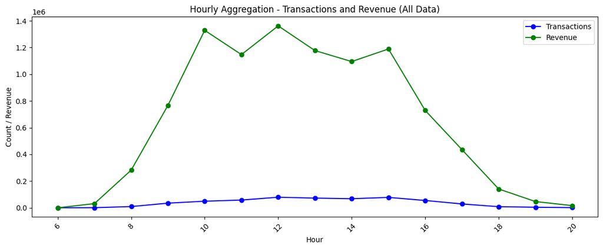

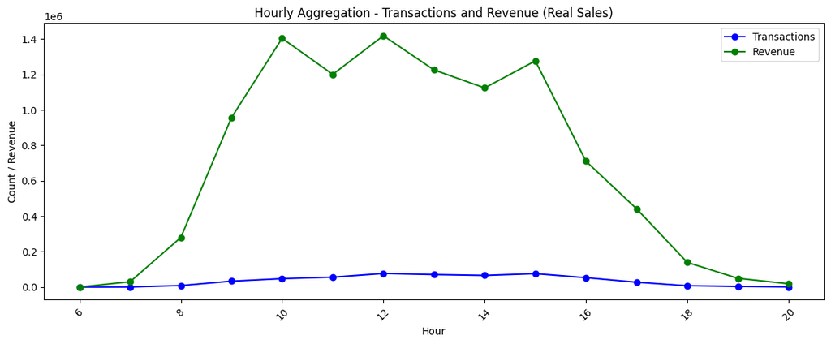

```python
# transaction volume and revenue by day of week (all)

hourly.plot(
    y=['Transactions','Revenue'],
    figsize=(14,5),
    title='Hourly Aggregation - Transactions and Revenue (All Data)',
    color=['blue', 'green'],
    marker='o')
plt.xlabel('Hour')
plt.ylabel('Count / Revenue')
plt.legend()
plt.xticks(rotation=45)
plt.show()

# transaction volume and revenue by day of week (real sales)

hourly_real_sales.plot(
    y=['Transactions','Revenue'],
    figsize=(14,5),
    title='Hourly Aggregation - Transactions and Revenue (Real Sales)',
    color=['blue', 'green'],
    marker='o')
plt.xlabel('Hour')
plt.ylabel('Count / Revenue')
plt.legend()
plt.xticks(rotation=45)
plt.show()

# sales peak at noon
# peak period is from 10:00 to 15:00
```

- The highest volume of transactions occurs between 10:00 and 15:00, representing the core business hours for customer engagement.
- Sales typically peak at noon, suggesting a midday surge in ordering activity, potentially coinciding with lunch-break shopping.
- Transaction volume is minimal before 08:00 and drops significantly after 15:00, mirroring standard business hours in the UK.

#### 3.6 Rolling Temporal Analysis

##### 3.6.1 Aggregate Data - Rolling 7-day/30-day Average

```python
# create rolling averages

aggregate_day['Revenue_7d'] = aggregate_day['Revenue'].rolling(window=7).mean()
aggregate_day['Revenue_30d'] = aggregate_day['Revenue'].rolling(window=30).mean()

aggregate_day['Transactions_7d'] = aggregate_day['Transactions'].rolling(window=7).mean()
aggregate_day['Transactions_30d'] = aggregate_day['Transactions'].rolling(window=30).mean()

# real sales

aggregate_day_real_sales['Revenue_7d'] = aggregate_day_real_sales['Revenue'].rolling(window=7).mean()
aggregate_day_real_sales['Revenue_30d'] = aggregate_day_real_sales['Revenue'].rolling(window=30).mean()

aggregate_day_real_sales['Transactions_7d'] = aggregate_day_real_sales['Transactions'].rolling(window=7).mean()
aggregate_day_real_sales['Transactions_30d'] = aggregate_day_real_sales['Transactions'].rolling(window=30).mean()
```

##### 3.6.2 Plot Data - Rolling 7-day/30-day Averages

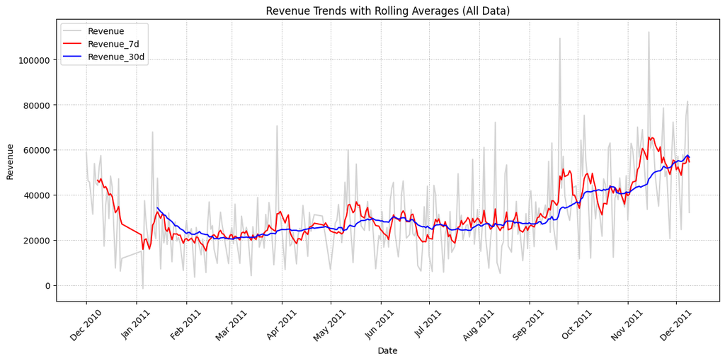

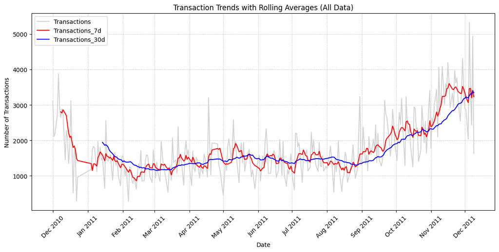

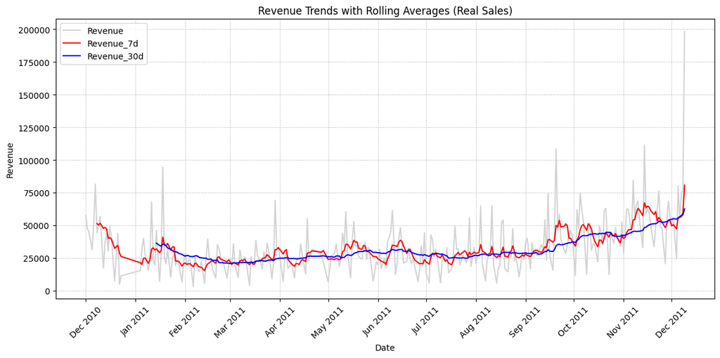

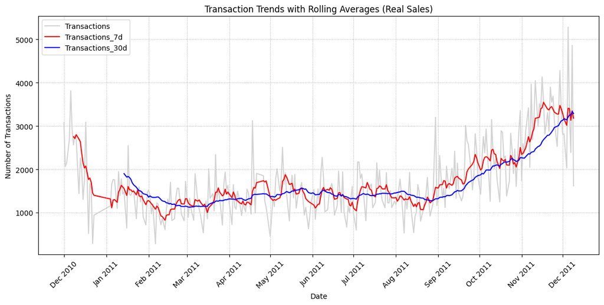

```python
# revenue trends

aggregate_day[['Revenue', 'Revenue_7d', 'Revenue_30d']].plot(
    figsize=(14,6),
    title='Revenue Trends with Rolling Averages (All Data)',
    color=['lightgray', 'red', 'blue']
)
plt.xlabel('Date')
plt.ylabel('Revenue')

plt.gca().xaxis.set_major_locator(mdates.MonthLocator())
plt.gca().xaxis.set_major_formatter(mdates.DateFormatter('%b %Y'))
plt.xticks(rotation=45)

plt.grid(True, linestyle=':')
plt.show()

# transaction trends

aggregate_day[['Transactions', 'Transactions_7d', 'Transactions_30d']].plot(
    figsize=(14,6),
    title='Transaction Trends with Rolling Averages (All Data)',
    color=['lightgray', 'red', 'blue']
)
plt.xlabel('Date')
plt.ylabel('Number of Transactions')

plt.gca().xaxis.set_major_locator(mdates.MonthLocator())
plt.gca().xaxis.set_major_formatter(mdates.DateFormatter('%b %Y'))
plt.xticks(rotation=45)

plt.grid(True, linestyle=':')
plt.show()

# revenue trends (real sales)

aggregate_day_real_sales[['Revenue', 'Revenue_7d', 'Revenue_30d']].plot(
    figsize=(14,6),
    title='Revenue Trends with Rolling Averages (Real Sales)',
    color=['lightgray', 'red', 'blue']
)
plt.xlabel('Date')
plt.ylabel('Revenue')

plt.gca().xaxis.set_major_locator(mdates.MonthLocator())
plt.gca().xaxis.set_major_formatter(mdates.DateFormatter('%b %Y'))
plt.xticks(rotation=45)

plt.grid(True, linestyle=':')
plt.show()

# transaction trends (real sales)

aggregate_day_real_sales[['Transactions', 'Transactions_7d', 'Transactions_30d']].plot(
    figsize=(14,6),
    title='Transaction Trends with Rolling Averages (Real Sales)',
    color=['lightgray', 'red', 'blue']
)
plt.xlabel('Date')
plt.ylabel('Number of Transactions')

plt.gca().xaxis.set_major_locator(mdates.MonthLocator())
plt.gca().xaxis.set_major_formatter(mdates.DateFormatter('%b %Y'))
plt.xticks(rotation=45)

plt.grid(True, linestyle=':')
plt.show()
```

- While raw data is highly volatile, analyzing "real sales" (filtered for returns and fees) reveals clearer underlying patterns. Transaction counts and revenue generally follow the same trajectory.
- A 7-day rolling average highlights a monthly cycle where activity peaks mid-month. This behavior is potentially linked to pay day cycles.
- The 30-day rolling average confirms a powerful seasonal trend. Sales ramp up significantly in the months preceding the holiday season (September–November) and decline sharply in the following months.
- While transaction volume shows stronger spikes, revenue growth is more steady. Larger revenue increases are concentrated in the pre-holiday period, suggesting higher-value orders during this time.

Annual Performance Dips:

- Mid-February & July/August: These periods represent the lowest transaction points of the year.
- A notable pickup occurs from mid-February to mid-May, likely driven by major retail events (Valentine's Day, Easter, Mother's Day).
- Following mid-May, transactions dip again through mid-August before rising rapidly as the fourth quarter approaches.